# Exploring French Fries

YOUR NAME

2021-03-08

# Exercise 3

1. Open french-fries.rmd and load the tidyverse package by replacing the ’___’ with the correct package

```r
#install.packages(c("tidyverse", "here"))
library(tidyverse)
```

2. Read in the french fries csv data file, is `french_fries` in long or wide format, how can you tell?

```r
french_fries <- read_csv(here::here("Week2-Tutorial-Solutions/data/french_fries.csv"))
french_fries
```

```
## # A tibble: 696 x 9
##     time treatment subject   rep potato buttery grassy rancid painty
##    <dbl>     <dbl>   <dbl> <dbl>  <dbl>   <dbl>  <dbl>  <dbl>  <dbl>
##  1     1         1       3     1    2.9     0      0      0      5.5
##  2     1         1       3     2   14       0      0      1.1    0
##  3     1         1      10     1   11       6.4    0      0      0
##  4     1         1      10     2    9.9     5.9    2.9    2.2    0
##  5     1         1      15     1    1.2     0.1    0      1.1    5.1
##  6     1         1      15     2    8.8     3      3.6    1.5    2.3
##  7     1         1      16     1    9       2.6    0.4    0.1    0.2
##  8     1         1      16     2    8.2     4.4    0.3    1.4    4
##  9     1         1      19     1    7       3.2    0      4.9    3.2
## 10     1         1      19     2   13       0      3.1    4.3   10.3
## # … with 686 more rows
```

3. The next code chunk converts the data to long form. What do you notice about each observation?

```r
fries_long <- french_fries %>%
  pivot_longer(cols = potato:painty,
               names_to = "type",
               values_to = "rating") %>%
  mutate(type = as.factor(type))
```

4. Filter french fries data using `filter()` to have:
   1. only week 1

```r
fries_long %>% filter(time == 1)
```

```
## # A tibble: 360 x 6
##     time treatment subject   rep type    rating
##    <dbl>     <dbl>   <dbl> <dbl> <fct>    <dbl>
##  1     1         1       3     1 potato     2.9
##  2     1         1       3     1 buttery    0
##  3     1         1       3     1 grassy     0
##  4     1         1       3     1 rancid     0
##  5     1         1       3     1 painty     5.5
##  6     1         1       3     2 potato    14
##  7     1         1       3     2 buttery    0
##  8     1         1       3     2 grassy     0
##  9     1         1       3     2 rancid     1.1
## 10     1         1       3     2 painty     0
## # … with 350 more rows
```

```
(b) weeks 1-4 only
```

```r
fries_long %>% filter(time %in% c("1", "2", "3", "4"))
```

```
## # A tibble: 1,440 x 6
##     time treatment subject   rep type    rating
##    <dbl>     <dbl>   <dbl> <dbl> <fct>    <dbl>
##  1     1         1       3     1 potato     2.9
##  2     1         1       3     1 buttery    0
##  3     1         1       3     1 grassy     0
##  4     1         1       3     1 rancid     0
##  5     1         1       3     1 painty     5.5
##  6     1         1       3     2 potato    14
##  7     1         1       3     2 buttery    0
##  8     1         1       3     2 grassy     0
##  9     1         1       3     2 rancid     1.1
## 10     1         1       3     2 painty     0
## # … with 1,430 more rows
```

```
(c) oil type 1 (oil type is called treatment)
```

```r
fries_long %>% filter(treatment == 1)
```

```
## # A tibble: 1,160 x 6
##     time treatment subject   rep type    rating
##    <dbl>     <dbl>   <dbl> <dbl> <fct>    <dbl>
##  1     1         1       3     1 potato     2.9
##  2     1         1       3     1 buttery    0
##  3     1         1       3     1 grassy     0
##  4     1         1       3     1 rancid     0
##  5     1         1       3     1 painty     5.5
##  6     1         1       3     2 potato    14
##  7     1         1       3     2 buttery    0
##  8     1         1       3     2 grassy     0
##  9     1         1       3     2 rancid     1.1
## 10     1         1       3     2 painty     0
## # … with 1,150 more rows
```

```
(d) oil types 1 and 3 but not 2
```

```r
fries_long %>% filter(treatment != 2)
```

```
## # A tibble: 2,320 x 6
##     time treatment subject   rep type    rating
##    <dbl>     <dbl>   <dbl> <dbl> <fct>    <dbl>
##  1     1         1       3     1 potato     2.9
##  2     1         1       3     1 buttery    0
##  3     1         1       3     1 grassy     0
##  4     1         1       3     1 rancid     0
##  5     1         1       3     1 painty     5.5
##  6     1         1       3     2 potato    14
##  7     1         1       3     2 buttery    0
##  8     1         1       3     2 grassy     0
##  9     1         1       3     2 rancid     1.1
## 10     1         1       3     2 painty     0
## # … with 2,310 more rows
```

5. Show the following variables using `select()`:
   1. choose time, treatment and rep

```r
fries_long %>% select(time, treatment, rep)
```

```
## # A tibble: 3,480 x 3
##     time treatment   rep
##    <dbl>     <dbl> <dbl>
##  1     1         1     1
##  2     1         1     1
##  3     1         1     1
##  4     1         1     1
##  5     1         1     1
##  6     1         1     2
##  7     1         1     2
##  8     1         1     2
##  9     1         1     2
## 10     1         1     2
## # … with 3,470 more rows
```

```
(b) choose subject through to rating
```

```r
fries_long %>% select(subject:rating)
```

```
## # A tibble: 3,480 x 4
##    subject   rep type    rating
##      <dbl> <dbl> <fct>    <dbl>
##  1       3     1 potato     2.9
##  2       3     1 buttery    0
##  3       3     1 grassy     0
##  4       3     1 rancid     0
##  5       3     1 painty     5.5
##  6       3     2 potato    14
##  7       3     2 buttery    0
##  8       3     2 grassy     0
##  9       3     2 rancid     1.1
## 10       3     2 painty     0
## # … with 3,470 more rows
```

```
(c) show everything except subject (drop subject)
```

```r
fries_long %>% select(-subject)
```

```
## # A tibble: 3,480 x 5
##     time treatment   rep type    rating
##    <dbl>     <dbl> <dbl> <fct>    <dbl>
##  1     1         1     1 potato     2.9
##  2     1         1     1 buttery    0
##  3     1         1     1 grassy     0
##  4     1         1     1 rancid     0
##  5     1         1     1 painty     5.5
##  6     1         1     2 potato    14
##  7     1         1     2 buttery    0
##  8     1         1     2 grassy     0
##  9     1         1     2 rancid     1.1
## 10     1         1     2 painty     0
## # … with 3,470 more rows
```

6. For the french fries data compute a new variable called lrating by taking a log of the rating using `mutate`

```r
fries_long %>%
  mutate(lrating = log10(rating))
```

```
## # A tibble: 3,480 x 7
##     time treatment subject   rep type    rating   lrating
##    <dbl>     <dbl>   <dbl> <dbl> <fct>    <dbl>     <dbl>
##  1     1         1       3     1 potato     2.9    0.462
##  2     1         1       3     1 buttery    0   -Inf
##  3     1         1       3     1 grassy     0   -Inf
##  4     1         1       3     1 rancid     0   -Inf
##  5     1         1       3     1 painty     5.5    0.740
##  6     1         1       3     2 potato    14      1.15
##  7     1         1       3     2 buttery    0   -Inf
##  8     1         1       3     2 grassy     0   -Inf
##  9     1         1       3     2 rancid     1.1    0.0414
## 10     1         1       3     2 painty     0   -Inf
## # … with 3,470 more rows
```

7. Use `group_by()` and `summarise()` to do the following:
   1. Compute the average rating by subject

```r
fries_long %>%
  group_by(subject) %>%
  summarise(rating = mean(rating, na.rm=TRUE))
```

```
## # A tibble: 12 x 2
##    subject rating
##  *   <dbl>  <dbl>
##  1       3   2.46
##  2      10   4.24
##  3      15   2.16
##  4      16   3.00
##  5      19   4.54
##  6      31   4.00
##  7      51   4.39
##  8      52   2.72
##  9      63   3.48
## 10      78   1.94
## 11      79   1.94
## 12      86   2.94
```

```
(b) Compute the average rancid rating per week
```

```r
fries_long %>%
  filter(type == "rancid") %>%
  group_by(time) %>%
  summarise(rating = mean(rating, na.rm=TRUE))
```

```
## # A tibble: 10 x 2
##     time rating
##  * <dbl>  <dbl>
##  1     1   2.36
##  2     2   2.85
##  3     3   3.72
##  4     4   3.60
##  5     5   3.53
##  6     6   4.08
##  7     7   3.89
##  8     8   4.27
##  9     9   4.67
## 10    10   6.07
```

8. Use `count()` to count the following:
   1. the number of subjects

```r
fries_long %>% count(subject, sort=TRUE)
```

```
## # A tibble: 12 x 2
##    subject     n
##      <dbl> <int>
##  1      10   300
##  2      15   300
##  3      16   300
##  4      19   300
##  5      51   300
##  6      52   300
##  7      63   300
##  8      78   300
##  9       3   270
## 10      31   270
## 11      79   270
## 12      86   270
```

```
(b) the number of types
```

```r
fries_long %>% count(type)
```

```
## # A tibble: 5 x 2
##   type        n
## * <fct>   <int>
## 1 buttery   696
## 2 grassy    696
## 3 painty    696
## 4 potato    696
## 5 rancid    696
```

# Exercise 4: Data analysis

1. Are the `rating`s for each `type` similar?

```r
fries_long %>%
  group_by(type) %>%
  summarise(m = mean(rating,
                     na.rm = TRUE),
            sd = sd(rating,
                    na.rm = TRUE)) %>%
  arrange(-m)
```

```
## # A tibble: 5 x 3
##   type        m    sd
##   <fct>   <dbl> <dbl>
## 1 potato  6.95   3.58
## 2 rancid  3.85   3.78
## 3 painty  2.52   3.39
## 4 buttery 1.82   2.41
## 5 grassy  0.664  1.32
```

```
## Warning: Removed 9 rows containing non-finite values (stat_boxplot).
```

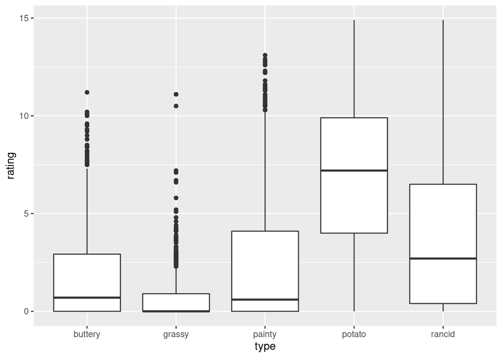

```r
ggplot(fries_long,
       aes(x = type,
           y = rating)) +
  geom_boxplot()
```

*Note: the plot prints but you see a warning, this is because there are 9 rows that are missing a rating*

**Answer: The scales of the ratings are quite different. Mostly the chips are rated highly on potato’y, but low on grassy.**

2. Are the replicates (`reps`) like each other?
   1. Pivot the fries_long dataset wide to show the `rating` for `rep` 1 and `rep` 2 in their own column

```r
fries_spread <- fries_long %>%
  pivot_wider(names_from = rep,
              values_from = rating)

fries_spread
```

```
## # A tibble: 1,740 x 6
##     time treatment subject type      `1`   `2`
##    <dbl>     <dbl>   <dbl> <fct>   <dbl> <dbl>
##  1     1         1       3 potato    2.9  14
##  2     1         1       3 buttery   0     0
##  3     1         1       3 grassy    0     0
##  4     1         1       3 rancid    0     1.1
##  5     1         1       3 painty    5.5   0
##  6     1         1      10 potato   11     9.9
##  7     1         1      10 buttery   6.4   5.9
##  8     1         1      10 grassy    0     2.9
##  9     1         1      10 rancid    0     2.2
## 10     1         1      10 painty    0     0
## # … with 1,730 more rows
```

```
(b) Plot the ratings for rep 1 and 2 and add a title to the plot with a short summary of the data quality
```

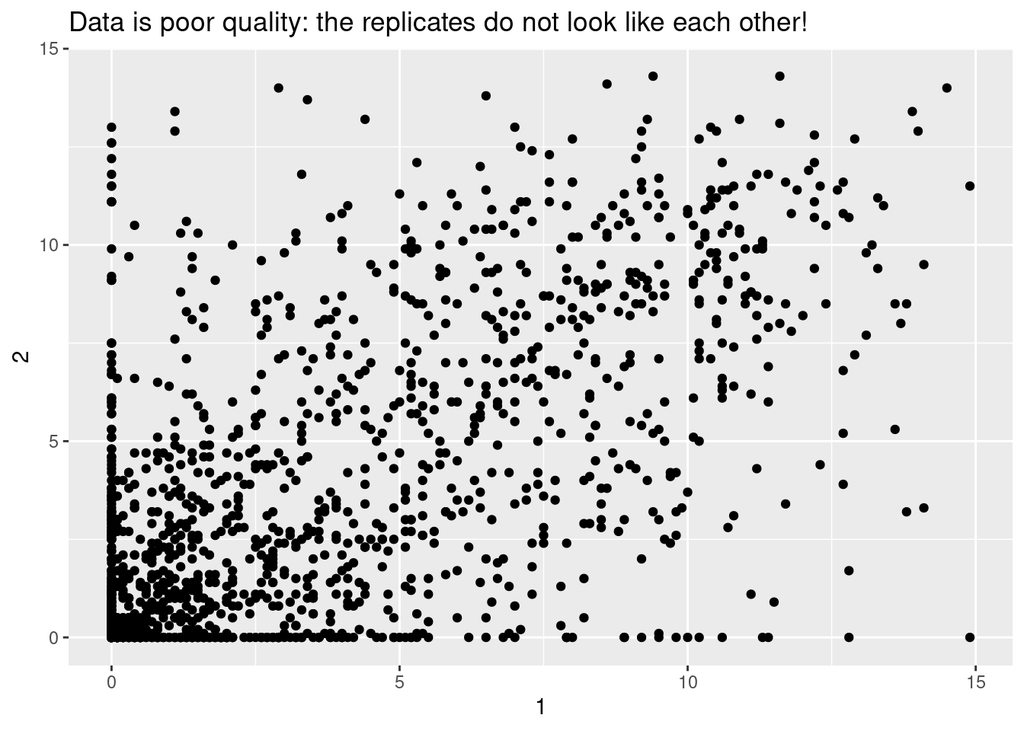

```r
  ggplot(fries_spread,
         aes(x = `1`,
             y = `2`)) +
  geom_point() +
  labs(title = "Data is poor quality: the replicates do not look like each other!")
```